# sd4answers

1. Code to read in data and generate plots:

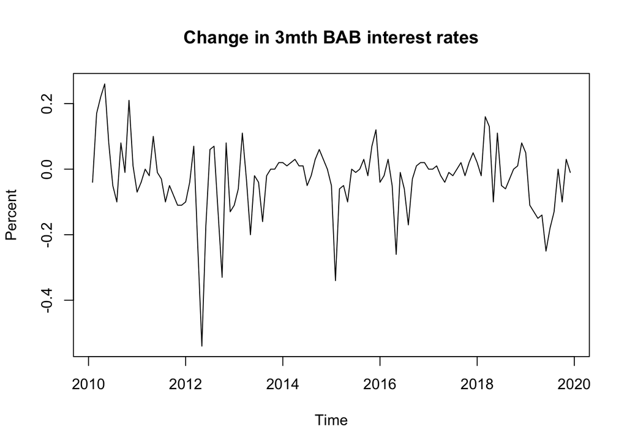

   ```r
   dt <- read.csv("BAB3mth.csv")
   Y <- ts(dt$BAB3, start=c(2010,1), end=c(2025,6), frequency=12)
   Y <- window(Y, end=c(2020,12))
   DY <- diff(Y)
   Time <- time(DY)
   t_est <- which(Time<2020)
   plot(window(DY, end=c(2019,12)), ylab="Percent",
        main="Change in 3mth BAB interest rates")
   ```

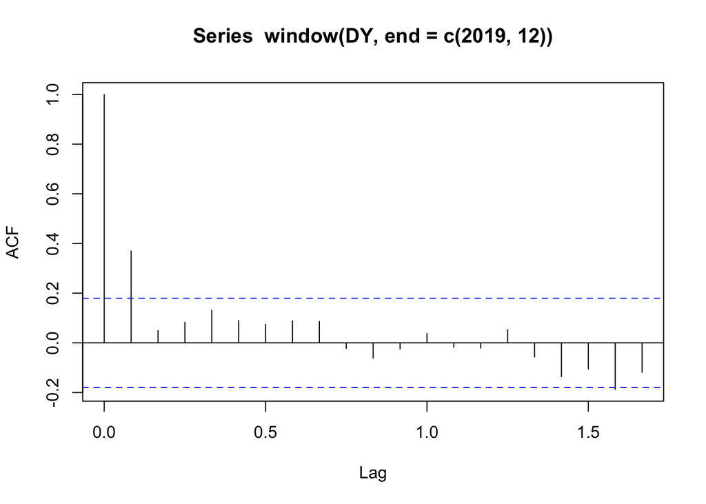

   ```r
   acf(window(DY, end=c(2019,12)))
   ```

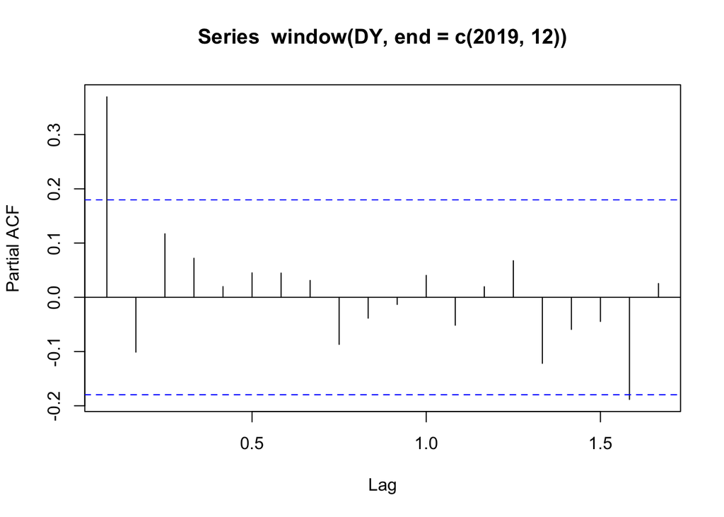

   ```r
   pacf(window(DY, end=c(2019,12)))
   ```

   There is no clear evidence of a need to introduce other variables to the deterministic regression for the mean. A constant mean is included in the model by default.

   The acf and pacf both have significant first order correlations, but little evidence of correlations at higher lags in either. As often the case, this means the acf/pacf are not definitive on the appropriate model. Nevertheless the implication is that a model with AR or MA orders above 1 seems unlikely.
2. Here is code to generate the required combinations of models. (Note this sort of broad model search may sometimes cause estimation problems, for reasons we will return to later.)

   ```r
   library(forecast)
   t_est <- which(time(DY)<2020)
   pmax <- 3
   qmax <- 3
   AICc <- matrix(nrow=pmax+1, ncol=qmax+1)
   rownames(AICc) <- paste0("p=",0:pmax)
   colnames(AICc) <- paste0("q=",0:qmax)
   LBp <- AICc
   for (p in 0:pmax){
     for (q in 0:qmax){
       ARMApq <- Arima(DY[t_est], order=c(p,0,q))
       AICc[p+1,q+1] <- ARMApq$aicc
       capture.output(LBp[p+1,q+1] <- checkresiduals(ARMApq,
                                           plot=FALSE)$p.value)
     }
   }
   print(round(LBp,3))
   ```

   ```
         q=0   q=1   q=2   q=3
   p=0 0.007 0.926 0.901 0.839
   p=1 0.776 0.902 0.845 0.899
   p=2 0.838 0.592 0.892 0.790
   p=3 0.942 0.967 0.925 0.799
   ```

   The only model that fails the residual autocorrelation test is $p=0$ and $q=0$, i.e. with no modelling of the autocorrelation in the time series. All other ARMA models pass the residual autocorrelation test.

   ```r
   print(round(AICc,3))
   ```

   ```
            q=0      q=1      q=2      q=3
   p=0 -187.796 -204.810 -202.772 -200.594
   p=1 -203.023 -202.777 -201.640 -199.600
   p=2 -202.139 -198.839 -199.466 -200.513
   p=3 -201.575 -200.455 -198.211 -197.828
   ```

   The AICc implies the MA(1) model is preferred.
3. Here is the command for the MA(1) forecast:

   ```r
   MA1 <- Arima(DY[t_est], order=c(0,0,1))
   MA1Forecast <- forecast(MA1, h=1)$mean
   print(c(MA1Forecast))
   ```

   ```
   [1] -0.03654358
   ```

   To understand how this works, the MA(1) model in R is represented
   $$\begin{align}
   Y_t &= \mu + Z_t\\
   Z_t &= U_t + \theta_1 U_{t-1}
   \end{align}$$
   which implies the one-step-ahead forecast
   $$E(Y_t | {\mathscr{Y}}_{t-1}) = \mu + \theta_1 U_{t-1}.$$
   Following estimation we obtain the coefficients $\hat\theta_1$ (labelled “ma1” in R) and $\hat\mu$ (“intercept”), and the residuals $\widehat{U}_t$, which enables the computation of the forecast
   $$\widehat{E}(Y_t | {\mathscr{Y}}_{t-1}) = \widehat\mu +
   \widehat\theta_1 \widehat{U}_{t-1}.$$
   The R code that spells out these steps is as follows, showing the match with the `forecast` command above.

   ```r
   n <- length(t_est)
   U <- MA1$residuals
   print(MA1$coef["intercept"]+MA1$coef["ma1"]*U[n])
   ```

   ```
     intercept
   -0.03654358
   ```

4. To show how ARMA(1,1) forecasting works, here is the R code using `forecast`:

   ```r
   ARMA11 <- Arima(DY[t_est], order=c(1,0,1))
   ARMA11Forecast <- forecast(ARMA11, h=1)$mean
   print(c(ARMA11Forecast))
   ```

   ```
   [1] -0.03331345
   ```

   The ARMA(1,1) model in R is represented
   $$\begin{align}
   Y_t &= \mu + Z_t\\
   Z_t &= \phi_1 Z_{t-1} + U_t + \theta_1 U_{t-1}
   \end{align}$$
   which implies the one-step-ahead forecast
   $$E(Y_t | {\mathscr{Y}}_{t-1}) = \mu + \phi_1 Z_{t-1} + \theta_1 U_{t-1}.$$
   The coefficient estimates are $\hat\theta_1$ (“ma1”), $\hat\phi_1$ (“ar1”) and $\hat\mu$ (“intercept”), and the residuals $\widehat{U}_t$. The R code to replicate this is as follows.

   ```r
   U <- ARMA11$residuals
   Z <- DY[t_est]-ARMA11$coef["intercept"]
   print(ARMA11$coef["intercept"]
         +ARMA11$coef["ar1"]*Z[n]
         +ARMA11$coef["ma1"]*U[n])
   ```

   ```
     intercept
   -0.03331345
   ```